# Time Series Forecasting

Olena Medvedyeva

#### Estimation of Missing Data with Mean Value

[1] “There are no Missing Data in this Data Set”

#### Estimation of Missing Data with Linear Interpolation

[1] “There are no Missing Data in this Data Set”

#### AutoFitting Linear Model

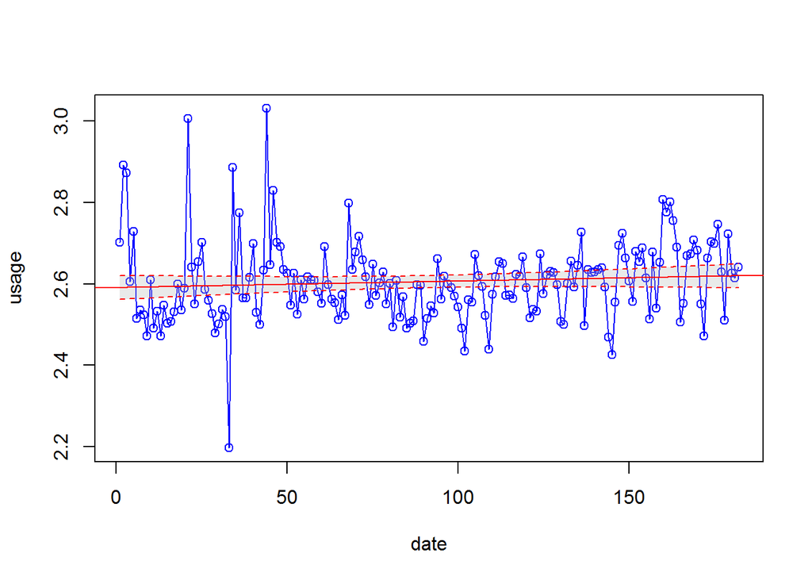

[1] “Confidence intervals are” 2.5 % 97.5 % (Intercept) 2.5614569 2.620716 example0_ordered$day -0.0001237 0.000438

From this output, we have determined that the intercept is 2.59 and the coefficient is 0.0001571. Therefore, the complete regression equation is Usage = 2.59 + 0.0001571 * Time. This equation tells us that the predicted usage almost will not increase with time. Suppose that our research question asks what the expected usage is. As follows, we can use the regression equation to calculate the answer to this question.

Let’s check model summary

Call: lm(formula = example0_ordered$usage ~ example0_ordered$day)

Residuals: Min 1Q Median 3Q Max -0.3997 -0.0627 -0.0062 0.0460 0.4327

Coefficients: Estimate Std. Error t value Pr(>|t|)  
(Intercept) 2.591086 0.015016 172.6 <2e-16 *** example0_ordered$day 0.000157 0.000142 1.1 0.27  
— Signif. codes: 0 ‘**’ 0.001 ’**’ 0.01 ’’ 0.05 ‘.’ 0.1 ‘’ 1

Residual standard error: 0.101 on 180 degrees of freedom Multiple R-squared: 0.00673, Adjusted R-squared: 0.00121 F-statistic: 1.22 on 1 and 180 DF, p-value: 0.271

0% R-squared indicates that the model explains none of the variability of the response data around its mean.

After fitting a regression model, we should consider various diagnostic plots. In the case of time series regression, an important diagnostic plot is the correlogram of the residuals:

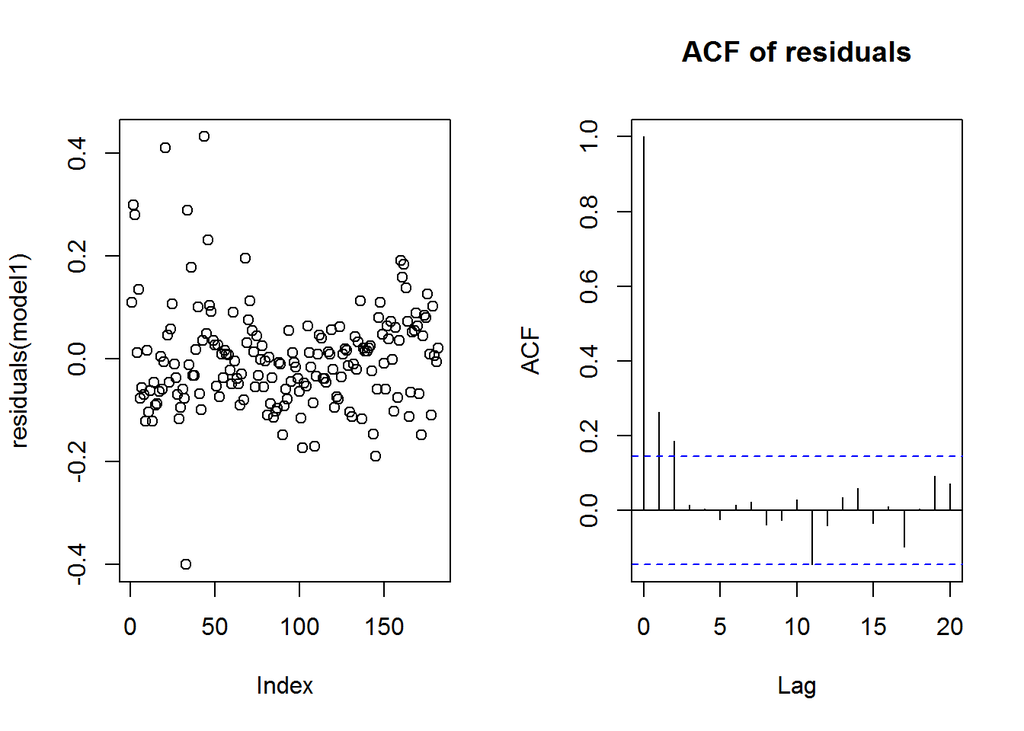

We can see that there is an autocorrelation left in the residuals (seen in the significant spike in the ACF plot). This suggests that the model can be improved. We will come back to improving later. At first, we will fit linear models that are calculated manualy.

#### Manual Fitting Linear Model in Matrix Form

[1] “Estimated Coeficients are” [,1][1,] 2.5910865 [2,] 0.0001571

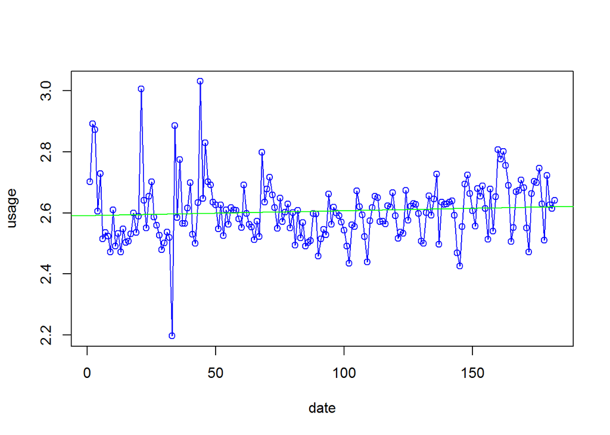

#### Linear Regression with Gradient Descent

[1] “Estimated Coeficients are” [,1][1,] 2.5910758 [2,] 0.0001572

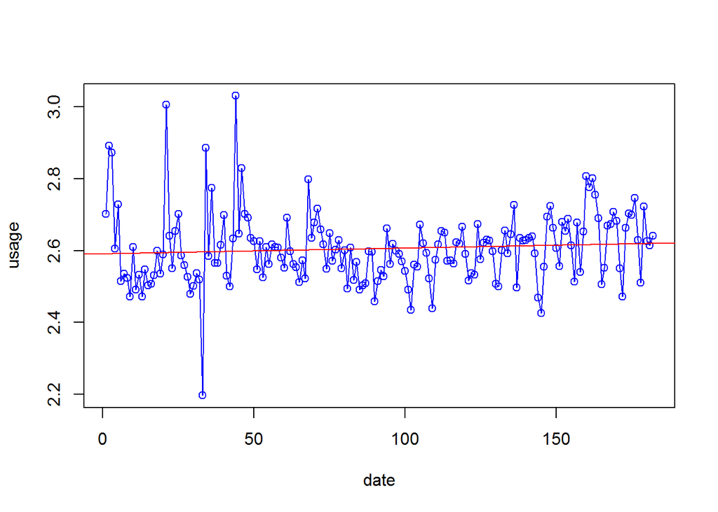

We can see that both manually built models are almost the same as fitted using R command.

Now, let’s try to fit the data better with other models.

#### Forecasts using Exponential Smoothing

Exponential smoothing can be used to make short-term forecasts for time series data. You can see from the plot that there is roughly constant level (the mean stays constant at about 2.6). Thus, we can make forecasts using simple exponential smoothing.

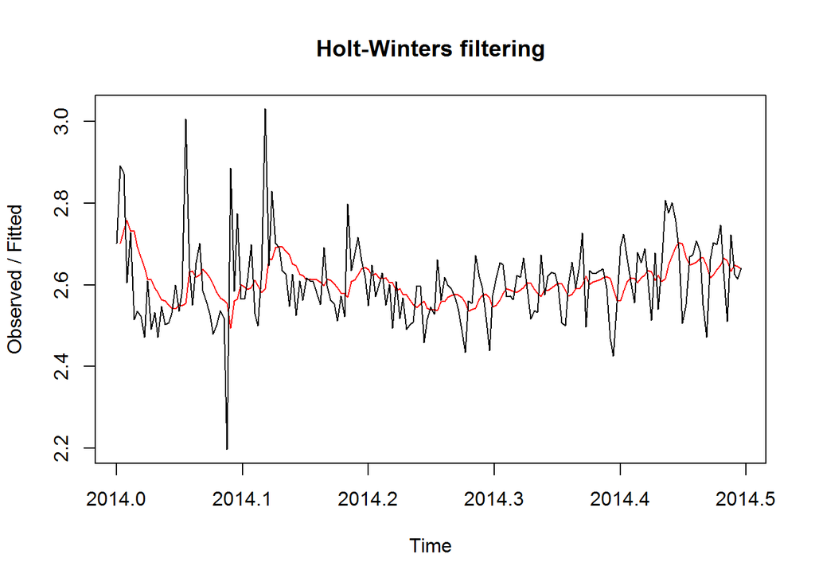

[1] " " Holt-Winters exponential smoothing without trend and without seasonal component.

Call: HoltWinters(x = example_ts, beta = FALSE, gamma = FALSE)

Smoothing parameters: alpha: 0.1704 beta : FALSE gamma: FALSE

Coefficients: [,1] a 2.64

The plot shows the original time series in black, and the forecasts as a red line. The time series of forecasts is much smoother than the time series of the original data here.

The output of HoltWinters() tells us that the estimated value of the alpha parameter is about 0.17. It means that older data points are weighted more heavily.

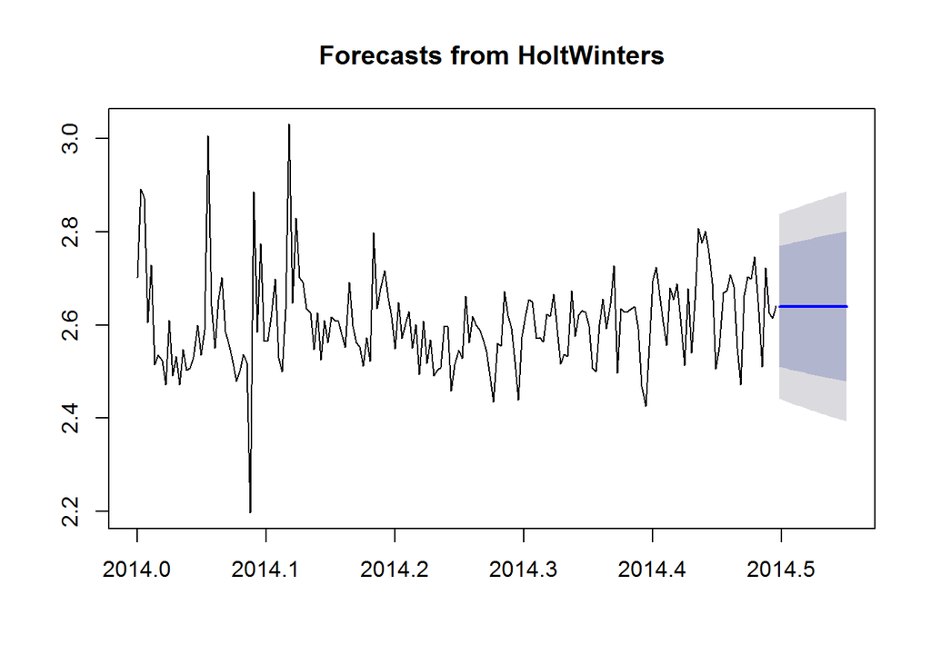

On this plot you can see prediction for upcoming 20 days with 80% and 95% prediction intervals.

If the predictive model cannot be improved upon, there should be no correlations between forecast errors for successive predictions. In other words, if there are correlations between forecast errors for successive predictions, it is likely that the simple exponential smoothing forecasts could be improved upon by another forecasting technique.

To figure out whether this is the case, we can obtain a correlogram of the in-sample forecast errors for lags 1-20.

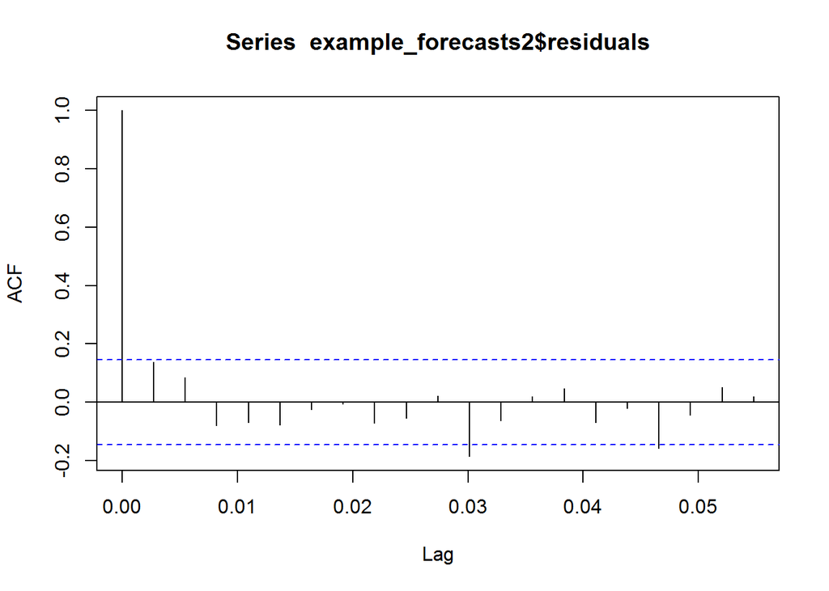

You can see from the sample correlogram that the autocorrelation at lag 1, 11 and 17 are just touching the significance bounds. To test whether there is significant evidence for non-zero correlations at lags 1-20, we can carry out a Ljung-Box test.

```
Box-Ljung test
```

data: example_forecasts2$residuals X-squared = 24.89, df = 20, p-value = 0.2056

#### ARIMA

While exponential smoothing methods do not make any assumptions about correlations between successive values of the time series, ARIMA models include an explicit statistical model for the irregular component of a time series, that allows non-zero autocorrelations in the irregular component.

#### Differencing a Time Series

If we start off with a non-stationary time series, first we need to difference the time series until we obtain a stationary time series. In our case the time series is stationary.

When our time series is stationary, the next step is to select the appropriate ARIMA model, which means finding the values of most appropriate values of p and q for an ARIMA(p,d,q) model. To do this, we need to examine the correlogram and partial correlogram of the stationary time series.

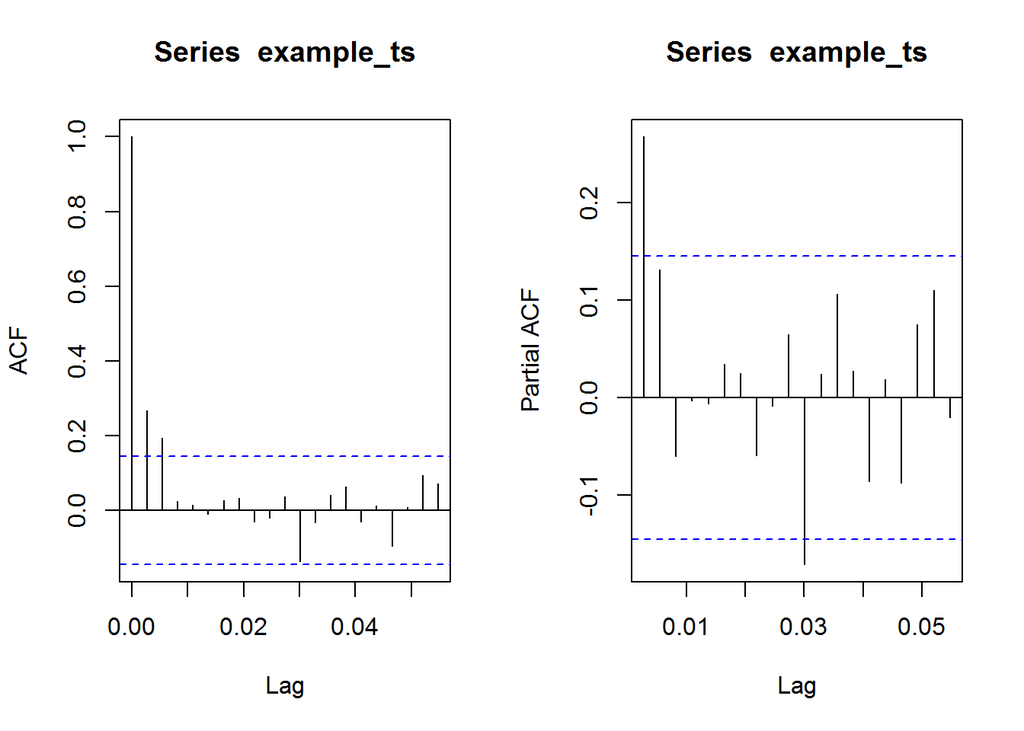

Since the correlogram tends to zero after lag 2, and the partial correlogram shows correlations at lag 1 and 11, this the following ARMA (autoregressive moving average) models are possible for the time series:

- an ARMA(2,0) model, that is, an autoregressive model of order p = 2
- an ARMA(0,2) model, that is, a moving average model of order q = 2, since the autocorrelogram is zero after lag 2
- an ARMA(p,q) model, that is, a mixed model with p and q greater than 0, since the autocorrelogram and partial correlogram tail off to zero (although the correlogram probably tails off to zero too abruptly for this model to be appropriate)

We use the principle of parsimony to decide which model is best: that is, we assume that the model with the fewest parameters is best. Thus, let’s take the ARMA(2,0) model.

An ARIMA(2,0,0) model is an autoregressive model of order 2, or AR(2) model.

#### Autofitting ARIMA models

Series: example_ts ARIMA(3,0,0) with non-zero mean

Coefficients: ar1 ar2 ar3 intercept 0.239 0.150 -0.054 2.606 s.e. 0.074 0.076 0.076 0.011

sigma^2 estimated as 0.0092: log likelihood=168.4 AIC=-326.8 AICc=-326.4 BIC=-310.8

As a result we are proposed to use ARIMA(3,0,0) model.But let’s fix to our chosen model ARIMA(2,0,0).

#### ARIMA forecast

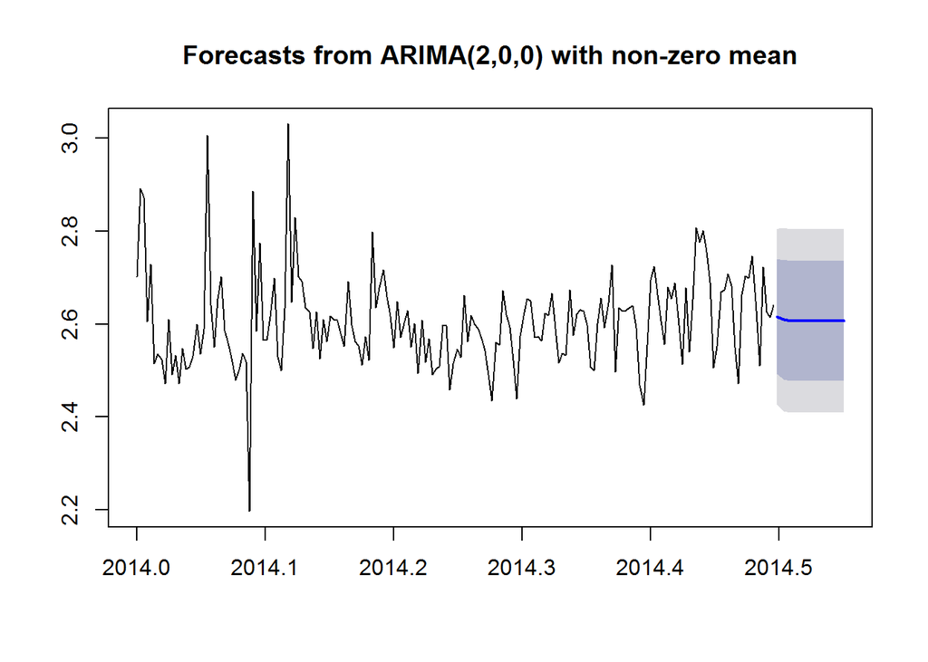

We obtained forecast for the next 20 days usage with 80% and 95% prediction intervals.

Now it’s a good idea to investigate whether the forrecast errors of an ARIMA model are normally distributed with mean zero and constant variance, and whether there are correlations between successive forecast errors.

#### ARIMA MODEL VALIDATION

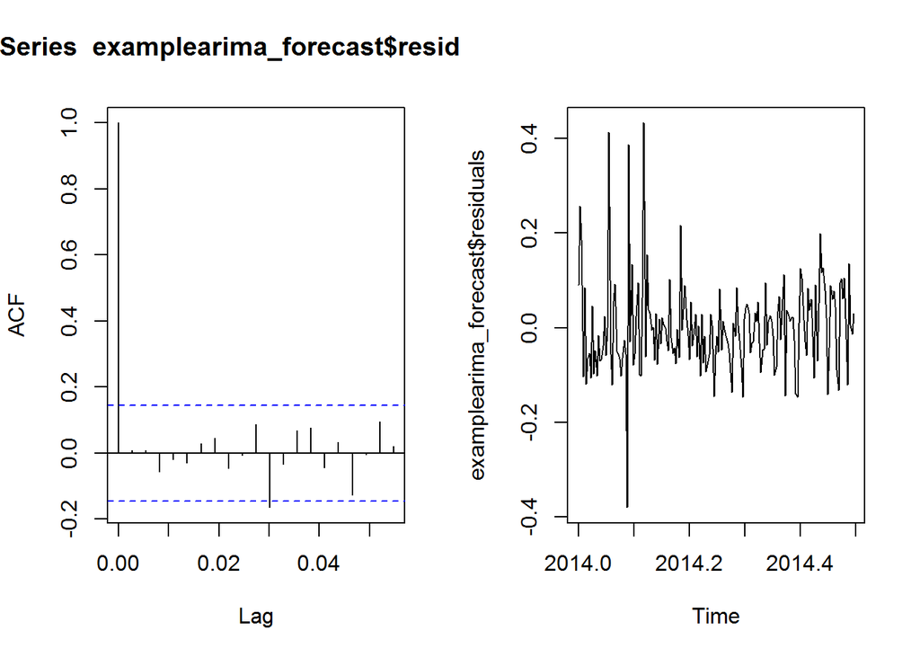

Box-Ljung test

data: examplearima_forecast$residuals X-squared = 16.71, df = 20, p-value = 0.6716

Since the correlogram shows only one exceding the significance bounds (which could happen due to chance), and p-value for the Ljung-Box test is 0.67, we can conclude that there is just small evidence for non-zero autocorrelations in the forecast errors at lags 1-20.

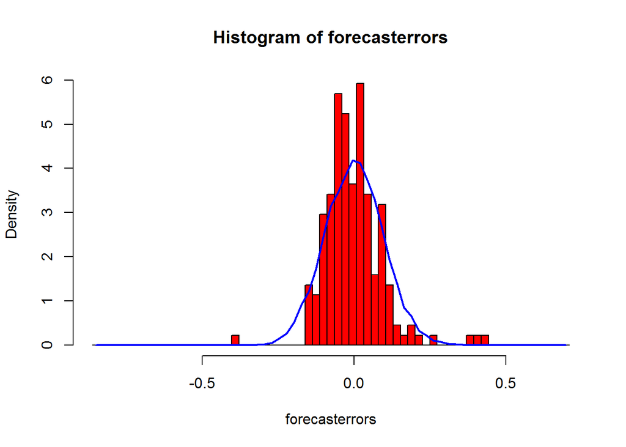

Since succesive forecast errors do not seem to be correlated, and the forecast errors seem to be normaly distributed with mean zero and constant variance, the ARIMA(2,0,0) (or AR(2)) does seem to provide an adequate predictive model.

For the last step let’s compare results of our Linear and ARIMA models. For that we devided our Data Set into two parts - a training one (75% of all data points), and a test one (25% of all data points). After that we compare predictions that are built and real values from the testing set.

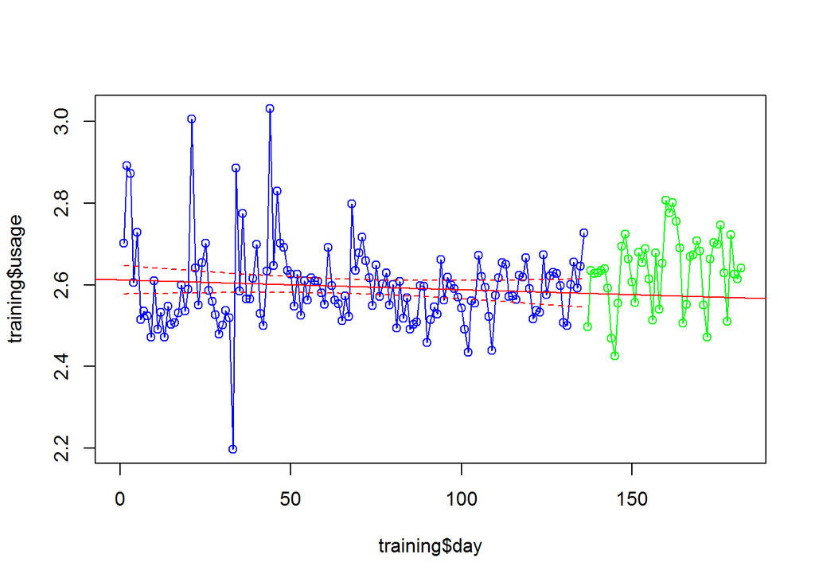

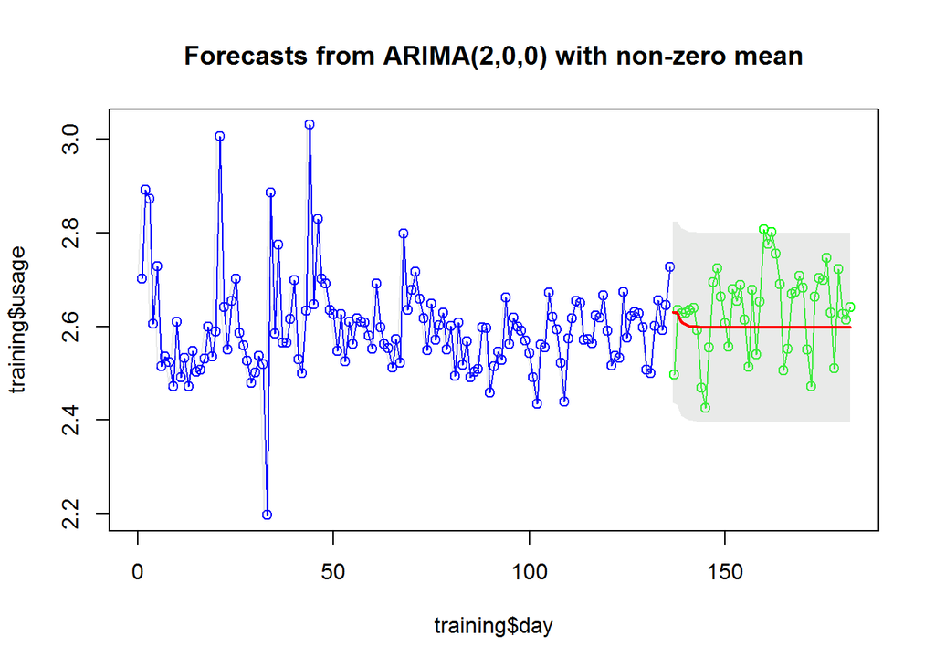

As we can see from the plots, linear model that was built on smaller ammount of data points is absolutelly different from the previous one. At the same time, ARIMA (2,0,0) model still gives acceptable results.